# Assignment 2

Descriptive Statistics and Reliability Concepts

SYSEN 5300/6300

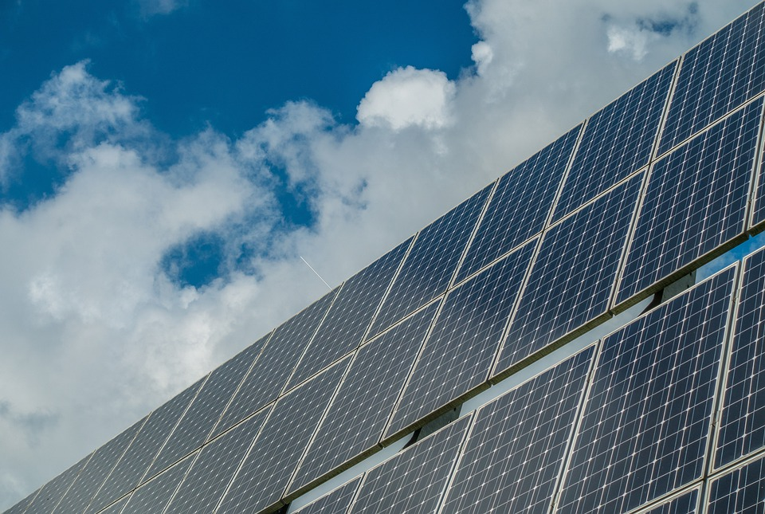

Solar Panels Everywhere!

# Prompt

In 2012, Japan’s parliament introduced policies to aggressively introduce renewable energy to make up for nuclear reactors gone offline after the 2011 disaster at the Fukushima Daiichi nuclear power plant. Since 2012, rates of renewable energy, particularly rooftop solar and ground-mounted solar farms, have skyrocketed in Japanese communities.

In this assignment, you will use your knowledge of **descriptive statistics**, **probability**, and **reliability** to analyze the introduction of this new technology, answering 8 questions using the `R` functions we have learned to date.

- Please work on it in a team of up to 6 members.
- Teams may talk to each other about how to approach the problems, but *we expect each team to do their own work.*
- Please submit a 1-2 page `.docx` file listing your responses.
- Please submit your team’s `.R` file, clearly commenting your code for each step.
- *(All values below are hypothetical, unless otherwise indicated, for educational purposes, but are meant to be plausible examples.)*

# Q1. Bayes Rule (10 points)

A firm new to the renewable energy sector decided to invest in a solar project. The firm tasks *your team* to determine which supplier to purchase solar panels from.

- You purchased `35%` percent of panels from **Mitsui**, which has as a shipment defect rate of `1%`.
- You purchased `20%` percent of panels from **Toshiba**, which ships `3%` defectives.
- You purchased the rest from **Kyocera**, which ships `0.5%` defectives.

During construction, your electrical engineer picks a panel at random, which turns out to be defective! What is the probability that this defective panel was manufactured by **Mitsui**, **Toshiba**, and **Kyocera**, respectively?

1. **(5 points)** You were given $P(Defective|Mitsui)$, $P(Defective|Toshiba)$, and $P(Defective|Kyocera)$. What are their values?
2. **(5 points)** Using Bayes’ rule, calculate $P(Mitsui|Defective)$, $P(Toshiba|Defective)$, and $P(Kyocera|Defective)$.

# Q2. ‘AND’ and ‘OR’ Relationships (15 points)

To figure out what went wrong, you read up more on this company’s panels, and discover that it has three main components, including (A) solar cell layer, (B) tempered glass, and (C) an electrical junction box. Upon further research…

- The *solar cell layer* has a probability of `0.01` of failing in 1 year.
- The *glass* has a probability of `0.03` of failing in 1 year.
- The *junction box* has a probability of `0.05` of failing in 1 year.
- Assume that the solar cells, tempered glass, and junction box are *all independent* (the failure of one component has nothing to do with other components). What is the probability that the panel *survives* 1 year without failing?

1. **(5 points)** $P(panel \ survives) = P(Cell \ survives \ \textbf{AND} \ Glass \ survives \ \textbf{AND} \ Junction \ Box \ survives)$
2. **(5 points)** $P(panel \ survives) = 1 - P(Cell \ fails \ \textbf{OR} \ Glass \ fails \ \textbf{OR} \ Junction \ Box \ fails)$
3. **(5 points)** Are they the same? Why or why not? (Hint: A Venn Diagram may help.)

# Q3. Bayes Rule (5 points)

Your team gets hired to add rooftop solar panels to homes in a **Tokyo** suburb, at the height of the COVID-19 pandemic. To keep your team and the community you are working in safe, your team masks, gets vaccinated, and regularly takes COVID tests.

- Suppose that `8.5%` of local residents are infected with COVID-19.
- Also, suppose that a COVID-19 antigen test will correctly flag as ‘positive’ `94%` of people who actively have COVID-19.
- However, like all other diagnostic tests, 2% of residents who *do not* have COVID-19 will also test positive.

Q. **(5 points)** Please calculate the probability that an employee who tests positive for COVID-19 actually has COVID.

# Q4. Uniform Distributions (10 points)

Your firm is on a tight deadline and needs 400 components for a new solar farm set to begin construction this week, but your regular supplier lost your order! To make it up to you, their sales rep agrees to sell you every part they produce on the assembly line for up to 1 week. The assembly line takes between 15 to 20 minutes to produce each component, and runs constantly. However, your contract requires you to start construction within 5 days!

Please investigate the following:

1. **(5 points)** Calculate the mean time to production (`mu`) in *days* for `400` components. Calculate also the standard deviation in production time (`sigma`) for `400` components.

**Click here for Hint!**

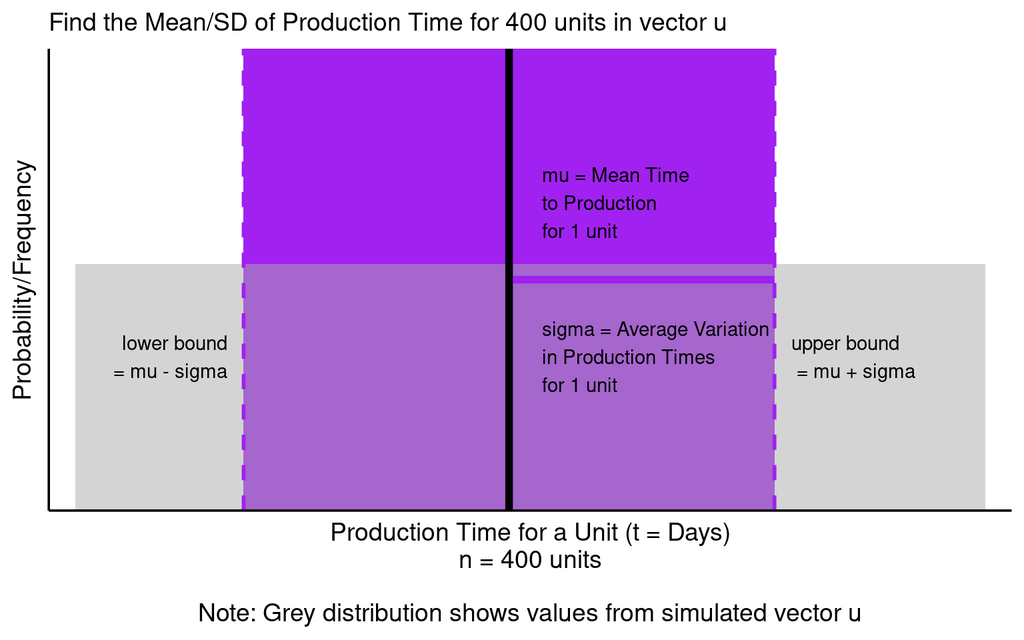

Visual Hint: Find mu and sigma

2. **(5 points)** On average, how many components can you expect to get within 5 days (`mu5`)? How much do you expect that number to vary, **on average**?
- *Note 2.1: By vary on average, we mean Lower and Upper bounds for 1 Standard Deviation from Mean.*
- *Note 2.2: We will accept (1) `lower5` and `upper5` or (2) `sigma5` from visual hint below.*

**Click here for Hint!**

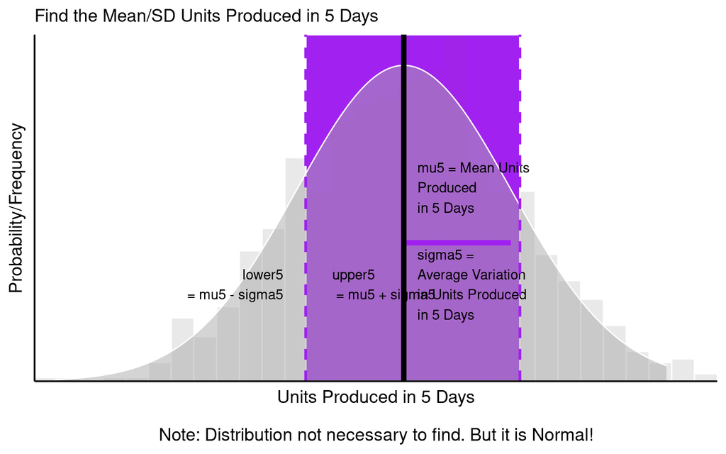

Visual Hint: Find (1) mu5 AND (2a) lower5 and upper5 OR (2b) sigma5

3. **BONUS: (5 points)** What’s the probability that the supplier will produce at least `400` parts within your deadline of 5 days? (*Hint*: use the statistics you calculated in step 2…)

**Click here for Hint!**

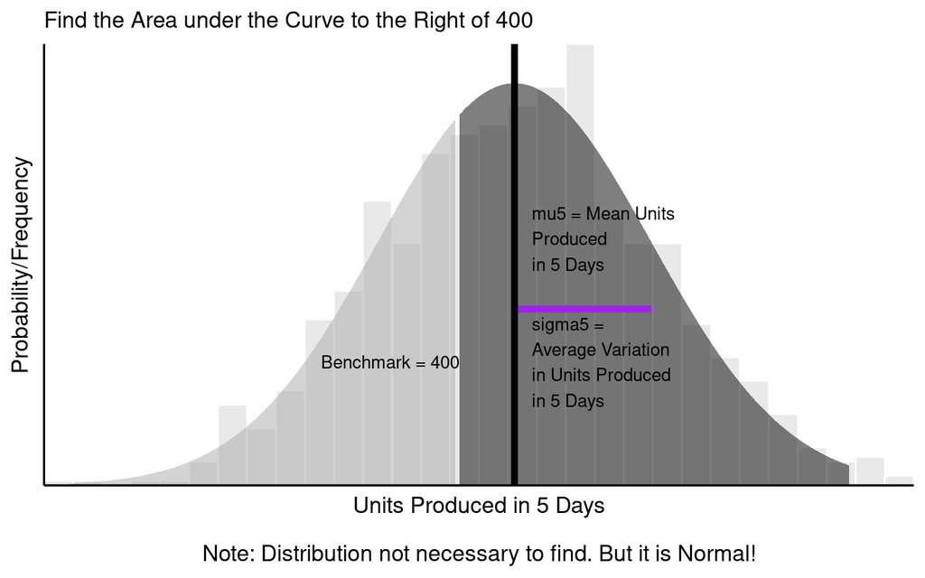

Visual Hint: Find p-value for black shaded region

# Q5. Simulation (10 points)

Tohoku University researchers wants to promote the local rooftop solar market in `400` nearby municipalities, so they hire your team to research it. They know from a firm’s survey that as of 2019, each of these `400` municipalities have adopted a mean of `459` units and a median of `400` units, with a standard deviation of `300.4` units. Unfortunately, there is no raw data left to work with!

1. **(5 points)** Based on the type of data being analyzed, which theoretical distribution is most likely to match the distribution of rooftop solar units? Why?
2. **(5 points)** Using that distribution, simulate the approximate cumulative probability of solar adoption in these 400 Tohoku municipalities, from 0 to 1000. How many municipalities do you project have adopted *more* than 400, 450, and 500 rooftop solar units to date, respectively?

# Q6. Interpreting Reliability (15 points)

# Q7. Survival Functions (10)

The [National Renewable Energy Lab](https://www.nrel.gov/news/program/2017/failures-pv-panels-degradation.html) estimates that solar panels installed between 2000 and 2015 failed a *constant annual rate* of just 5 panels per 10,000 panels. Your company installed 500 solar panels to form a single solar farm outside of Tokyo in 2012.

1. **(2.5 points)** What’s the probability that at all 500 of these panels survived years 10 years without failing? How about just 250 of these panels? 100 panels?
2. **(5 points)** Please calculate these probabilities for each year from 0 to 10 and visualize the 3 curves using `ggplot2` in `R`. Be sure to effectively label your plot, use color, and themes.
3. **(2.5 points)** Finally, please calculate the accumulative hazard rate for 1 solar panel by year 10.

# Q8. System Reliability (20 points)

**Prompt**: Your firm is hired to install an off-grid rooftop solar system on top of a community center, to provide power for this key neighborhood resource for up to 72 hours after crisis. Local leaders want to know *exactly* how likely this system is to survive, considering that it involves several component parts. Your team researches each component’s probability of failure and make the flowchart below.

- 75% of the year, the panels will get sufficient sunlight to function reliably.
- Each panel has a constant rate of failure at `0.06%` per year. (*Note: 0.06 PERCENT, not 6%.*)
- Each storage unit has a constant rate of failure at `2%` per year.
- All other components have a constant rate of failure at `1%` per year.

However, local leaders need to know the *overall reliability* of this system in a year!

**Questions**:

1. **(10 points)** Calculate the overall reliability of this system in *any* year $t$. (Note: Use *years* as your time unit of interest.)
2. **(10 points)** Create an `R` function to estimate the overall reliability of this system in *any* year. Then use it to visualize the overall reliability of the system over 20 years (0 to 20) in `ggplot2`.
- *Hint*: Write a general failure and/or reliability `function` (eg. `f` or `r`) first to make your code cleaner and easier.

[interactive chart not shown]

Community Center Solar System Diagram

# End

Congratulations! You made it! Please submit your answers and code on Canvas (1 set per team), and go relax!

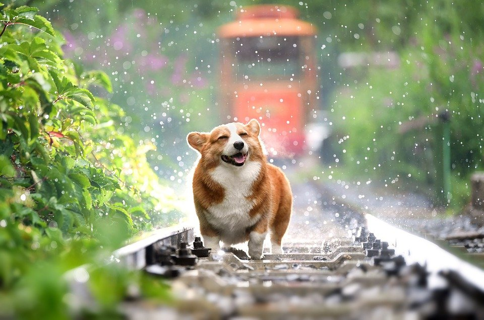

All done!